# PRUEBA FINAL PROGRAMACION ESTADISTICA

Cristian Sebastian Luna Pérez

17 de June de 2025

## Presentación del Proyecto

**Nombre:** Cristian Sebastian Luna Pérez  
**Programa:** Maestría en Estadística con Mención en Inteligencia Artificial y Ciencia de Datos  
**Materia:** Fundamentos de Programación Estadística  
**Docente:** Msc. Isaac Torres

## Gráfico 1: Dispersión 3D (lstat vs rm vs medv)

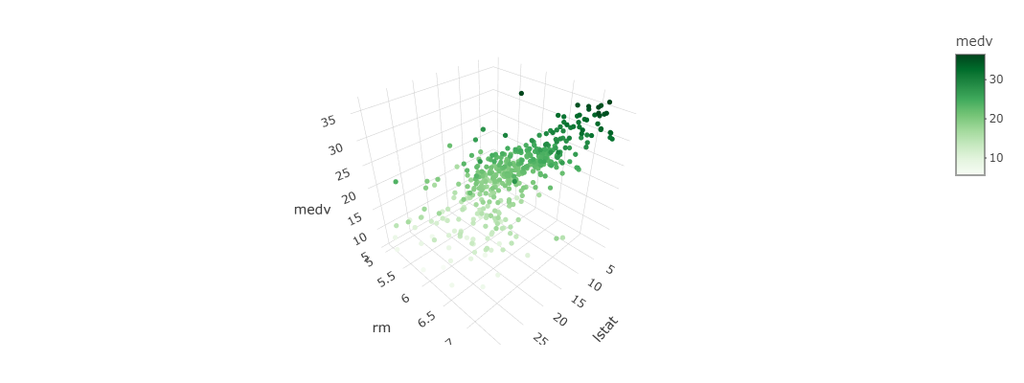

**Análisis:**  
El gráfico 3D muestra la interacción entre las variables `lstat`, `rm` y `medv`. Se puede observar que los valores de `medv` tienden a aumentar a medida que `rm` sube y `lstat` baja. La densidad de puntos en zonas altas de `medv` destaca agrupamientos de viviendas con mejores condiciones estructurales y socioeconómicas.

## Gráfico 2: Histograma con densidad - lstat

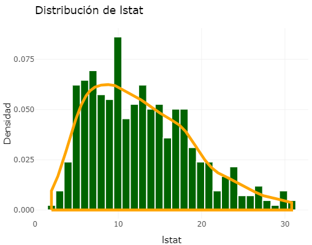

**Análisis:**  
La variable `lstat` presenta una distribución asimétrica hacia la derecha, con la mayoría de los valores concentrados entre 5 y 15. El histograma combinado con la curva de densidad revela una presencia significativa de barrios con población en situación de desventaja socioeconómica, lo que puede influir negativamente en el valor de la vivienda.

## Gráfico 3: Dispersión 2D con LOESS (lstat vs medv)

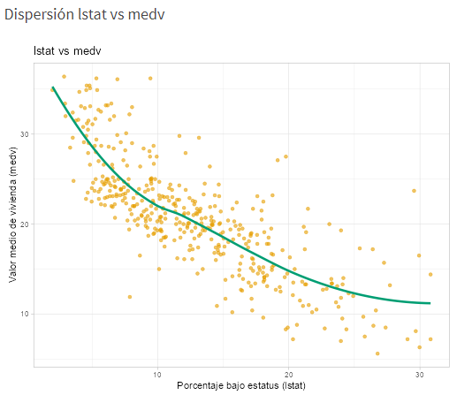

**Análisis:**  
Existe una relación inversa entre `lstat` y `medv`: a mayor proporción de población con bajo estatus, menor es el valor medio de las viviendas. La línea de suavizado LOESS permite detectar esta tendencia no lineal, especialmente notable en los extremos del rango de `lstat`.